# Step1_LoadData

Yang Lei

2024-07-11

**Codechuck 0. Loading data – Generating Recurrence Covariates**

*Step 0: Analytic data, Step 1: Proxy sources, Step 2: Emperical, Step 3: Recurrence*

```r
# ------------------- Select proxy based on the results from out2
# ------------------- change the code after Step 3: Recurrence
load("data/analytic3cycles.RData")

analytic <- data.complete
idx <- analytic$id
outcome <- as.numeric(analytic$diabetes == "Yes")
exposure <- as.numeric(analytic$obese == "Yes")

domain <- "dx"
analytic.dfx <- as.data.frame(cbind(idx, exposure, outcome, domain))
dat.proxy.long <- subset(dat.proxy.long,
                         icd10 != "E66") # Overweight and obesity
dat.proxy.long <- subset(dat.proxy.long,
                         icd10 != "O24") # Gestational diabetes mellitus
dat.proxy.long <- subset(dat.proxy.long,
                         icd10 != "E10") # Type 1 diabetes mellitus
dat.proxy.long <- subset(dat.proxy.long,
                         icd10 != "E11") # Type 2 diabetes mellitus
proxy.var.long <- dat.proxy.long
proxy.var.long$idx <- proxy.var.long$id
proxy.var.long$id <- NULL
dfx <- merge(analytic.dfx, proxy.var.long, by = "idx")
# ------------------- now the proxy data was combined to the A and Y

# basetable <- dfx %>% select(idx, exposure, outcome) %>% distinct()
basetable <- dfx[, c(1:3)] %>% distinct()
patientIds <- basetable$idx
length(patientIds)
```

```
## [1] 7585
```

```r
# ------------------- number of observations

save(dfx, patientIds, basetable, file = "data/dfx.RData")
load(file = "data/dfx.RData")

step1 <- get_candidate_covariates(df = dfx,
                                  domainVarname = "domain",
                                  eventCodeVarname = "icd10",
                                  patientIdVarname = "idx",
                                  patientIdVector = patientIds,
                                  n = 200,
                                  min_num_patients = 20)
```

```r
out1 <- step1$covars_data
# ------------------- top 200 prevalent icd10 with min 20 patients

step2 <- get_recurrence_covariates(df = out1,
                                   patientIdVarname = "idx",
                                   eventCodeVarname = "icd10",
                                   patientIdVector = patientIds)
out2 <- step2$recurrence_data

exposure <- "obese"
outcome <- "diabetes"
investigator.specified.covariates <-
  c(# Demographic
    "age.cat", "sex", "education", "race",
    "marital", "income", "born", "year",

    # health history related variables/access
    "diabetes.family.history", "medical.access",

    # behavioral
    "smoking", "diet.healthy", "physical.activity", "sleep",

    # Laboratory
    "uric.acid", "protein.total", "bilirubin.total", "phosphorus",
    "sodium", "potassium", "globulin", "calcium.total",
    "systolicBP", "diastolicBP", "high.cholesterol"
  )
```

**Method 1: Bross Formula**

```r
start_time <- Sys.time()
out3 <- get_prioritised_covariates(df = out2,
                                   patientIdVarname = "idx",
                                   exposureVector = basetable$exposure,
                                   outcomeVector = basetable$outcome,
                                   patientIdVector = patientIds,
                                   k = 100)
hdps.dim <- out3$autoselected_covariate_df

load("data/analytic3cycles.RData")
hdps.dim$id <- hdps.dim$idx
hdps.dim$idx <- NULL
hdps.data <- merge(data.complete[,c("id",
                                    outcome,
                                    exposure,
                                    investigator.specified.covariates)],
                   hdps.dim, by = "id")

hdps.data$exposure <- as.numeric(I(hdps.data$obese=='Yes'))
hdps.data$outcome <- as.numeric(I(hdps.data$diabetes=='Yes'))

proxy.list.sel <- names(out3$autoselected_covariate_df[,-1])
proxyform <- paste0(proxy.list.sel, collapse = "+")
covform <- paste0(investigator.specified.covariates, collapse = "+")
rhsformula <- paste0(c(covform, proxyform), collapse = "+")
ps.formula <- as.formula(paste0("exposure", "~", rhsformula))


W.out <- weightit(ps.formula,
                  data = hdps.data,
                  estimand = "ATE",
                  method = "ps")
out.formula <- as.formula(paste0("outcome", "~", "exposure"))
fit <- glm(out.formula,
           data = hdps.data,
           weights = W.out$weights,
           family= binomial(link = "logit"))
fit.summary <- summary(fit)$coef["exposure",
                                 c("Estimate",
                                   "Std. Error",
                                   "Pr(>|z|)")]
fit.ci <- confint(fit, level = 0.95)["exposure", ]
fit.summary_with_ci <- c(fit.summary, fit.ci)
fit.summary_with_ci
```

```
##     Estimate   Std. Error     Pr(>|z|)        2.5 %       97.5 %
## 4.201615e-01 3.806007e-02 2.465925e-28 3.456428e-01 4.948435e-01
```

```r
fs.bross <- proxy.list.sel
sum_ci.bross <- c(exp(fit.summary_with_ci[1]), fit.summary_with_ci)
names(sum_ci.bross) <- c("Odds Ratio",
                          "Estimate",
                          "Std. Error",
                          "Pr(>|z|)",
                          "2.5 %",
                          "97.5 %")

print("No need to print the number of proxy variables selected, as it is set to be 100.")
```

```
## [1] "No need to print the number of proxy variables selected, as it is set to be 100."
```

```r
print("The Odds Ratio by Bross Formula")
```

```
## [1] "The Odds Ratio by Bross Formula"
```

```r
round(sum_ci.bross, 3)
```

```
## Odds Ratio   Estimate Std. Error   Pr(>|z|)      2.5 %     97.5 %
##      1.522      0.420      0.038      0.000      0.346      0.495
```

```r
end_time <- Sys.time()
elapsed_time.bross <- as.numeric(difftime(end_time, start_time, units = "secs"))
```

**Method 2: Hybrid Bross Formula & Lasso**

```r
set.seed(42)
start_time <- Sys.time()
proxy.list <- names(out3$autoselected_covariate_df[,-1])
covarsTfull <- c(investigator.specified.covariates, proxy.list)
Y.form <- as.formula(paste0(c("outcome~ exposure",
                              covarsTfull), collapse = "+") )
covar.mat <- model.matrix(Y.form, data = hdps.data)[,-1]
lasso.fit<-glmnet::cv.glmnet(y = hdps.data$outcome,
                             x = covar.mat,
                             type.measure='mse',
                             family="binomial",
                             alpha = 1,
                             nfolds = 5)
coef.fit<-coef(lasso.fit,s='lambda.min',exact=TRUE)
sel.variables<-row.names(coef.fit)[which(as.numeric(coef.fit)!=0)]
proxy.list.sel.hybrid <- proxy.list[proxy.list %in% sel.variables]
length(proxy.list.sel.hybrid)
```

```
## [1] 49
```

```r
fs.hybrid <- proxy.list.sel.hybrid

proxyform <- paste0(proxy.list.sel.hybrid, collapse = "+")
rhsformula <- paste0(c(covform, proxyform), collapse = "+")
ps.formula <- as.formula(paste0("exposure", "~", rhsformula))

W.out <- weightit(ps.formula,
                  data = hdps.data,
                  estimand = "ATE",
                  method = "ps")

out.formula <- as.formula(paste0("outcome", "~", "exposure"))
fit <- glm(out.formula,
           data = hdps.data,
           weights = W.out$weights,
           family= binomial(link = "logit"))
fit.summary <- summary(fit)$coef["exposure",
                                 c("Estimate",
                                   "Std. Error",
                                   "Pr(>|z|)")]
fit.ci <- confint(fit, level = 0.95)["exposure", ]
fit.summary_with_ci.h <- c(fit.summary, fit.ci)
sum_ci.hybrid <- c(exp(fit.summary_with_ci.h[1]), fit.summary_with_ci.h)

paste("The number of proxy variables selected:", length(proxy.list.sel.hybrid))
```

```
## [1] "The number of proxy variables selected: 49"
```

```r
print("All proxy variables selected are in common as they are all selected from
      the proxy variable list by the bross formula")
```

```
## [1] "All proxy variables selected are in common as they are all selected from \n      the proxy variable list by the bross formula"
```

```r
print("The Odds Ratio by Bross Formula & Lasso")
```

```
## [1] "The Odds Ratio by Bross Formula & Lasso"
```

```r
round(sum_ci.hybrid, 3)
```

```
##   Estimate   Estimate Std. Error   Pr(>|z|)      2.5 %     97.5 %
##      1.543      0.434      0.038      0.000      0.359      0.509
```

```r
end_time <- Sys.time()
elapsed_time.hybrid <- as.numeric(difftime(end_time, start_time, units = "secs"))
elapsed_time.hybrid
```

```
## [1] 7.052747
```

*Before implementing other methods, drop the information from method 1 (Bross formula). Continue with the results from Step 3: Recurrence (table `out2`).*

```r
hdps.dim <- out2

load("data/analytic3cycles.RData")
hdps.dim$id <- hdps.dim$idx
hdps.dim$idx <- NULL
hdps.data <- merge(data.complete[,c("id",
                                    outcome,
                                    exposure,
                                    investigator.specified.covariates)],
                   hdps.dim, by = "id")

hdps.data$exposure <- as.numeric(I(hdps.data$obese=='Yes'))
hdps.data$outcome <- as.numeric(I(hdps.data$diabetes=='Yes'))

proxy.list.sel <- names(out2[,-1])
proxyform <- paste0(proxy.list.sel, collapse = "+")
covform <- paste0(investigator.specified.covariates, collapse = "+")
rhsformula <- paste0(c(covform, proxyform), collapse = "+")
ps.formula <- as.formula(paste0("exposure", "~", rhsformula))

proxy.list <- names(out2[,-1])    # length(proxy.list) :  142
covarsTfull <- c(investigator.specified.covariates, proxy.list)
Y.form <- as.formula(paste0(c("outcome~ exposure",
                              covarsTfull), collapse = "+") )
```

**Method 3: Pure Lasso**

```r
set.seed(42) # different seed -> different length for the selected proxy list
start_time <- Sys.time()
covar.mat <- model.matrix(Y.form, data = hdps.data)[,-1]
lasso.fit <- glmnet::cv.glmnet(y = hdps.data$outcome,
                               x = covar.mat,
                               type.measure='mse',
                               family="binomial",
                               alpha = 1,
                               nfolds = 5)
coef.fit<-coef(lasso.fit,s='lambda.min',exact=TRUE)
sel.variables<-row.names(coef.fit)[which(as.numeric(coef.fit)!=0)]
proxy.list.sel.ml <- proxy.list[proxy.list %in% sel.variables]
length(proxy.list.sel.ml)
```

```
## [1] 60
```

```r
fs.lasso <- proxy.list.sel.ml
proxy.lasso <- paste0(fs.lasso, collapse = "+")
form.lasso <- paste0(c(covform, proxy.lasso), collapse = "+")
formula.lasso <- as.formula(paste0("exposure", "~", form.lasso))

W.out.lasso <- weightit(formula.lasso,
                        data = hdps.data,
                        estimand = "ATE",
                        method = "ps")

hdps.data$ps.l <- W.out.lasso$ps
hdps.data$w.l <- W.out.lasso$weights
out.formula <- as.formula(paste0("outcome", "~", "exposure"))
out.formula
```

```
## outcome ~ exposure
```

```r
fit.lasso <- glm(out.formula,
                 data = hdps.data,
                 weights = W.out.lasso$weights,
                 family= binomial(link = "logit"))
summary.lasso <- summary(fit.lasso)$coef["exposure", c("Estimate", "Std. Error", "Pr(>|z|)")]
ci.lasso <- confint(fit.lasso, level = 0.95)["exposure", ]
sum_ci.lasso <- c(exp(summary.lasso[1]), summary.lasso, ci.lasso)
names(sum_ci.lasso) <- c("Odds Ratio",
                         "Estimate",
                         "Std. Error",
                         "Pr(>|z|)",
                         "2.5 %",
                         "97.5 %")

# Q1: How many proxy variables are in common?
# length(fs.lasso)  # 60 features selected by lasso
# length(fs.lasso[fs.lasso %in% fs.bross])  # 47 of 60 also selected by bross
print("How many proxy variables are in common?")
```

```
## [1] "How many proxy variables are in common?"
```

```r
paste("There are", length(fs.lasso), "features selected by lasso")
```

```
## [1] "There are 60 features selected by lasso"
```

```r
paste(length(fs.lasso[fs.lasso %in% fs.bross]), "of the", length(fs.lasso),
      "are also selected by the bross formula method")
```

```
## [1] "47 of the 60 are also selected by the bross formula method"
```

```r
# See which variables are not in common:
# fs.lasso[!(fs.lasso %in% fs.bross)]

# Q2: Odds ratio
print("The Odds Ratio by Method Pure Lasso")
```

```
## [1] "The Odds Ratio by Method Pure Lasso"
```

```r
sum_ci.lasso
```

```
##   Odds Ratio     Estimate   Std. Error     Pr(>|z|)        2.5 %       97.5 %
## 1.531204e+00 4.260546e-01 3.798238e-02 3.358665e-29 3.516906e-01 5.005867e-01
```

```r
end_time <- Sys.time()
elapsed_time.lasso <- as.numeric(difftime(end_time, start_time, units = "secs"))
elapsed_time.lasso
```

```
## [1] 8.780712
```

**Method 4: Elastic Net**

```r
set.seed(42)
start_time <- Sys.time()
covar.mat <- model.matrix(Y.form, data = hdps.data)[,-1]
elas.fit <- glmnet::cv.glmnet(y = hdps.data$outcome,
                             x = covar.mat,
                             type.measure='mse',
                             family="binomial",
                             alpha = 0.5,
                             nfolds = 5)
coef.fit<-coef(elas.fit, s='lambda.min', exact=TRUE)
sel.variables<-row.names(coef.fit)[which(as.numeric(coef.fit)!=0)]
proxy.list.sel.elastic <- proxy.list[proxy.list %in% sel.variables]
length(proxy.list.sel.elastic)
```

```
## [1] 69
```

```r
fs.elastic <- proxy.list.sel.elastic

proxy.elastic <- paste0(fs.elastic, collapse = "+")
form.elastic <- paste0(c(covform, proxy.elastic), collapse = "+")
formula.elastic <- as.formula(paste0("exposure", "~", form.elastic))

W.out.elastic <- weightit(formula.elastic,
                       data = hdps.data,
                       estimand = "ATE",
                       method = "ps")

hdps.data$ps.e <- W.out.elastic$ps
hdps.data$w.e <- W.out.elastic$weights
out.formula <- as.formula(paste0("outcome", "~", "exposure"))
out.formula
```

```
## outcome ~ exposure
```

```r
fit.elastic <- glm(out.formula,
                data = hdps.data,
                weights = W.out.elastic$weights,
                family= binomial(link = "logit"))
summary.elastic <- summary(fit.elastic)$coef["exposure", c("Estimate", "Std. Error", "Pr(>|z|)")]
ci.elastic <- confint(fit.elastic, level = 0.95)["exposure", ]
sum_ci.elastic <- c(exp(summary.elastic[1]), summary.elastic, ci.elastic)
names(sum_ci.elastic) <- c("Odds Ratio",
                         "Estimate",
                         "Std. Error",
                         "Pr(>|z|)",
                         "2.5 %",
                         "97.5 %")

# Q1: How many proxy variables are in common (Elastic Net vs Bross Formula)?
# length(fs.elastic)  # 69 features selected by elastic net
# length(fs.elastic[fs.elastic %in% fs.bross])  # 54 of 69 also selected by bross formula
print("How many proxy variables are in common?")
```

```
## [1] "How many proxy variables are in common?"
```

```r
paste("There are", length(fs.elastic), "features selected by elas")
```

```
## [1] "There are 69 features selected by elas"
```

```r
paste(length(fs.elastic[fs.elastic %in% fs.bross]), "of the", length(fs.elastic),
      "are also selected by the bross formula method")
```

```
## [1] "54 of the 69 are also selected by the bross formula method"
```

```r
# See which variables are not in common:
# fs.elastic[!(fs.elastic %in% fs.bross)]

# Q2: Odds ratio
print("The Odds Ratio by Elastic Net")
```

```
## [1] "The Odds Ratio by Elastic Net"
```

```r
sum_ci.elastic
```

```
##   Odds Ratio     Estimate   Std. Error     Pr(>|z|)        2.5 %       97.5 %
## 1.503744e+00 4.079583e-01 3.796526e-02 6.217775e-27 3.336255e-01 4.824545e-01
```

```r
end_time <- Sys.time()
elapsed_time.enet <- as.numeric(difftime(end_time, start_time, units = "secs"))
elapsed_time.enet
```

```
## [1] 9.620058
```

**Method 5: XGBoost**

```r
start_time <- Sys.time()
xgb_fit <- xgboost(data = covar.mat, label = hdps.data$outcome,
                    max.depth = 20, eta = 1, nthread = 2, nrounds = 5,
                    objective = "binary:logistic")
```

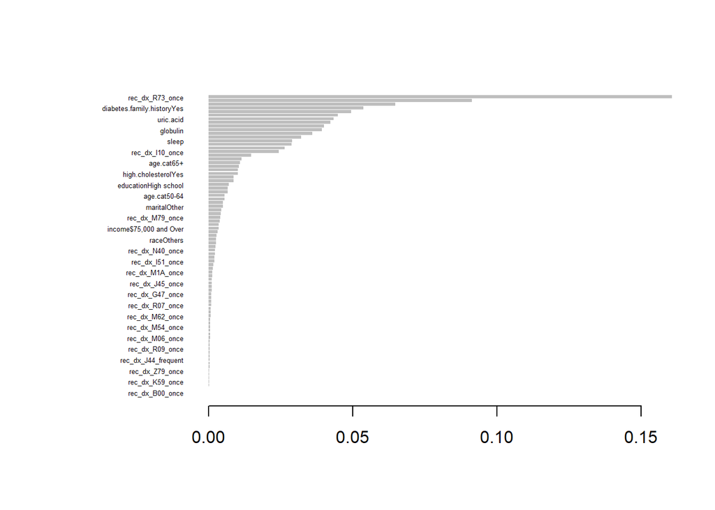

```r
xgb_imp <- xgb.importance(model = xgb_fit)
xgb.plot.importance(importance_matrix = xgb_imp)
```

```r
fs.xgboost <- xgb_imp$Feature
fs.xgboost <- proxy.list[proxy.list %in% fs.xgboost]
proxy.xgboost <- paste0(fs.xgboost, collapse = "+")
form.xgboost <- paste0(c(covform, proxy.xgboost), collapse = "+")
formula.xgboost <- as.formula(paste0("exposure", "~", form.xgboost))

W.out.xgboost <- weightit(formula.xgboost,
                          data = hdps.data,
                          estimand = "ATE",
                          method = "ps")

hdps.data$ps.xgboost <- W.out.xgboost$ps
hdps.data$w.xgboost <- W.out.xgboost$weights
out.formula <- as.formula(paste0("outcome", "~", "exposure"))
out.formula
```

```
## outcome ~ exposure
```

```r
fit.xgboost <- glm(out.formula,
                   data = hdps.data,
                   weights = W.out.xgboost$weights,
                   family= binomial(link = "logit"))
summary.xgboost <- summary(fit.xgboost)$coef["exposure", c("Estimate", "Std. Error", "Pr(>|z|)")]
ci.xgboost <- confint(fit.xgboost, level = 0.95)["exposure", ]
sum_ci.xgboost <- c(exp(summary.xgboost[1]), summary.xgboost, ci.xgboost)
names(sum_ci.xgboost) <- c("Odds Ratio",
                           "Estimate",
                           "Std. Error",
                           "Pr(>|z|)",
                           "2.5 %",
                           "97.5 %")

# Q1: How many proxy variables are in common?
# length(fs.xgboost)
# length(fs.xgboost[fs.xgboost %in% fs.bross])
print("How many proxy variables are in common?")
```

```
## [1] "How many proxy variables are in common?"
```

```r
paste("There are", length(fs.xgboost), "features selected by xgboost")
```

```
## [1] "There are 48 features selected by xgboost"
```

```r
paste(length(fs.xgboost[fs.xgboost %in% fs.bross]), "of the", length(fs.xgboost),
      "are also selected by the bross formula method")
```

```
## [1] "38 of the 48 are also selected by the bross formula method"
```

```r
# See which variables are not in common:
# fs.xgboost[!(fs.xgboost %in% fs.bross)]

# Q2: Odds ratio
print("The Odds Ratio by XGBoost")
```

```
## [1] "The Odds Ratio by XGBoost"
```

```r
sum_ci.xgboost
```

```
##   Odds Ratio     Estimate   Std. Error     Pr(>|z|)        2.5 %       97.5 %
## 1.564251e+00 4.474069e-01 3.803569e-02 6.067361e-32 3.729423e-01 5.220474e-01
```

```r
end_time <- Sys.time()
elapsed_time.xgb <- as.numeric(difftime(end_time, start_time, units = "secs"))
elapsed_time.xgb
```

```
## [1] 1.726237
```

**Method 6: GA**

*GA (Genetic Algorithm) has no specific internal model building mechanism and would wrap around whatever model the user specifies*

```r
start_time <- Sys.time()
gaOpt <- function(vars, IV.train, DV.train) {
    varNames <- colnames(IV.train) #getting names of all variables
    selectedVarNames <- varNames[vars == "1"] # getting names of selected vars from GA
    gaSolutionData <- IV.train[,selectedVarNames] # keeping only those selected vars

    gaDat <- cbind(gaSolutionData,DV.train) # combining selected variables with outcome variable
    gaMod <- glm(DV.train ~ ., family = "binomial", data = gaDat) #build model
    gaProb <- predict(gaMod, IV.train, type = "response") # get probabilities
    gaPred <- ifelse(gaProb >= .8, 1, 0) # get predicted 0s and 1s

    ari <- adjustedRandIndex(gaPred, DV.train)
    return(ari)
}

ga.solution <- ga(fitness = function(vars)
 gaOpt(vars=vars,
       IV.train=data.frame(covar.mat),
       DV.train=hdps.data$outcome),
 type = "binary",
 nBits = ncol(covar.mat),
 names = colnames(covar.mat),
 seed = 42,
 run=5)

allVarNames <- colnames(covar.mat)
sel.variables.GA <- allVarNames[ga.solution@solution[1,]==1]
fs.GA <- proxy.list[proxy.list %in% sel.variables.GA]
proxy.GA <- paste0(fs.GA, collapse = "+")
form.GA <- paste0(c(covform, proxy.GA), collapse = "+")
formula.GA <- as.formula(paste0("exposure", "~", form.GA))

W.out.GA <- weightit(formula.GA,
                         data = hdps.data,
                         estimand = "ATE",
                         method = "ps")

hdps.data$ps.ga <- W.out.GA$ps
hdps.data$w.ga <- W.out.GA$weights
out.formula <- as.formula(paste0("outcome", "~", "exposure"))
out.formula
```

```
## outcome ~ exposure
```

```r
fit.GA <- glm(out.formula,
                  data = hdps.data,
                  weights = W.out.GA$weights,
                  family= binomial(link = "logit"))
summary.GA <- summary(fit.GA)$coef["exposure", c("Estimate", "Std. Error", "Pr(>|z|)")]
ci.GA <- confint(fit.GA, level = 0.95)["exposure", ]
sum_ci.GA <- c(exp(summary.GA[1]), summary.GA, ci.GA)
names(sum_ci.GA) <- c("Odds Ratio",
                          "Estimate",
                          "Std. Error",
                          "Pr(>|z|)",
                          "2.5 %",
                          "97.5 %")

# Q1: How many proxy variables are in common (GA vs Bross Formula)?
# length(fs.GA)  # 64 features selected by GA
# length(fs.GA[fs.GA %in% fs.bross])  # 44 of 64 also selected by bross formula
print("How many proxy variables are in common?")
```

```
## [1] "How many proxy variables are in common?"
```

```r
paste("There are", length(fs.GA), "features selected by GA")
```

```
## [1] "There are 64 features selected by GA"
```

```r
paste(length(fs.GA[fs.GA %in% fs.bross]), "of the", length(fs.GA),
      "are also selected by the bross formula method")
```

```
## [1] "44 of the 64 are also selected by the bross formula method"
```

```r
# See which variables are not in common:
# fs.GA[!(fs.GA %in% fs.bross)]

# Q2: Odds ratio
print("The Odds Ratio by GA:")
```

```
## [1] "The Odds Ratio by GA:"
```

```r
sum_ci.GA
```

```
##   Odds Ratio     Estimate   Std. Error     Pr(>|z|)        2.5 %       97.5 %
## 1.514643e+00 4.151797e-01 3.802674e-02 9.445205e-28 3.407275e-01 4.897975e-01
```

```r
end_time <- Sys.time()
elapsed_time.ga <- as.numeric(difftime(end_time, start_time, units = "secs"))
elapsed_time.ga
```

```
## [1] 182.7802
```

**Method 7: Elastic SCAD SVM**

*Elastic SCAD SVM uses an approach like LASSO and Elastic Net in that it selects variables via the addition of a penalty.*

*(Long Running Time)*

```r
start_time <- Sys.time()
svmTrainOutcome <- hdps.data$outcome
svmTrainOutcome[svmTrainOutcome == 0] <- -1
svmTrainPreds <- data.frame(covar.mat)

bounds <- t(data.frame(log2lambda1=c(-10, 10), log2lambda2=c(-10,10)))
colnames(bounds)<-c("lower", "upper")
svm.model <- svmfs(x=covar.mat,
                   y = svmTrainOutcome,
                   fs.method = "scad+L2",
                   bounds=bounds,
                   grid.search = "interval",
                   inner.val.method = "cv",
                   show = "none",
                   parms.coding = "none",
                   seed=42)
```

[output not shown]

[output cut: 6500 more lines]

```r
fs.svm <- colnames(covar.mat)[svm.model$model$fit.info$model.list$model$xind]
fs.svm <- proxy.list[proxy.list %in% fs.svm]
proxy.svm <- paste0(fs.svm, collapse = "+")
form.svm <- paste0(c(covform, proxy.svm), collapse = "+")
formula.svm <- as.formula(paste0("exposure", "~", form.svm))

W.out.svm <- weightit(formula.svm,
                        data = hdps.data,
                        estimand = "ATE",
                        method = "ps")

hdps.data$ps.svm <- W.out.svm$ps
hdps.data$w.svm <- W.out.svm$weights
out.formula <- as.formula(paste0("outcome", "~", "exposure"))
out.formula
```

```
## outcome ~ exposure
```

```r
fit.svm <- glm(out.formula,
                 data = hdps.data,
                 weights = W.out.svm$weights,
                 family= binomial(link = "logit"))
summary.svm <- summary(fit.svm)$coef["exposure", c("Estimate", "Std. Error", "Pr(>|z|)")]
ci.svm <- confint(fit.svm, level = 0.95)["exposure", ]
sum_ci.svm <- c(exp(summary.svm[1]), summary.svm, ci.svm)
names(sum_ci.svm) <- c("Odds Ratio",
                         "Estimate",
                         "Std. Error",
                         "Pr(>|z|)",
                         "2.5 %",
                         "97.5 %")

# Q1: How many proxy variables are in common?
# length(fs.svm)
# length(fs.svm[fs.svm %in% fs.bross])
print("How many proxy variables are in common?")
```

```
## [1] "How many proxy variables are in common?"
```

```r
paste("There are", length(fs.svm), "features selected by svm")
```

```
## [1] "There are 1 features selected by svm"
```

```r
paste(length(fs.svm[fs.svm %in% fs.bross]), "of the", length(fs.svm),
      "are also selected by the bross formula method")
```

```
## [1] "1 of the 1 are also selected by the bross formula method"
```

```r
# See which variables are not in common:
# fs.svm[!(fs.svm %in% fs.bross)]

# Q2: Odds ratio
print("The Odds Ratio by Elastic SCAD SVM")
```

```
## [1] "The Odds Ratio by Elastic SCAD SVM"
```

```r
sum_ci.svm
```

```
##   Odds Ratio     Estimate   Std. Error     Pr(>|z|)        2.5 %       97.5 %
## 1.769309e+00 5.705892e-01 3.817373e-02 1.625130e-50 4.958817e-01 6.455281e-01
```

```r
end_time <- Sys.time()
elapsed_time.svm <- as.numeric(difftime(end_time, start_time, units = "secs"))
elapsed_time.svm
```

```
## [1] 5947.574
```

**Method 8: Boruta Selection**

*Boruta Selection would give the feature importance ranking based on the Random Forests algorithm which are able to capture some non-linear trends but not easy to interpret.*